# PML_courseraProject

ansprasad

3/13/2021

## Coursera Project - Practical Machine Learning

### Loading Libraries

```r
library(ggplot2)
library(caret)
library(doParallel)
library(e1071)
library(gbm)
library(survival)
library(splines)
library(plyr)
```

### Loading Data

Data is loaded after removing Div/0!

```r
training <- read.csv("pml-training.csv", na.strings=c("#DIV/0!"), row.names = 1)
testing <- read.csv("pml-testing.csv", na.strings=c("#DIV/0!"), row.names = 1)
```

### Cleaning NA and blank Columns

Totally there were 174 columns of loaded data after the previous step. However, there are several column which have high % of blank or NA data. Removing them should improve model performance. hence cleaning them up and creating good column list

```r
training <- training[, 6:dim(training)[2]]
treshold <- dim(training)[1] * 0.95
goodcols <- !apply(training, 2, function(x) sum(is.na(x)) > treshold  || sum(x=="") > treshold)
training <- training[, goodcols]
badcols <- nearZeroVar(training, saveMetrics = TRUE)
training <- training[, badcols$nzv==FALSE]
training$classe = factor(training$classe)
names(training)
```

```
##  [1] "num_window"           "roll_belt"            "pitch_belt"
##  [4] "yaw_belt"             "total_accel_belt"     "gyros_belt_x"
##  [7] "gyros_belt_y"         "gyros_belt_z"         "accel_belt_x"
## [10] "accel_belt_y"         "accel_belt_z"         "magnet_belt_x"
## [13] "magnet_belt_y"        "magnet_belt_z"        "roll_arm"
## [16] "pitch_arm"            "yaw_arm"              "total_accel_arm"
## [19] "gyros_arm_x"          "gyros_arm_y"          "gyros_arm_z"
## [22] "accel_arm_x"          "accel_arm_y"          "accel_arm_z"
## [25] "magnet_arm_x"         "magnet_arm_y"         "magnet_arm_z"
## [28] "roll_dumbbell"        "pitch_dumbbell"       "yaw_dumbbell"
## [31] "total_accel_dumbbell" "gyros_dumbbell_x"     "gyros_dumbbell_y"
## [34] "gyros_dumbbell_z"     "accel_dumbbell_x"     "accel_dumbbell_y"
## [37] "accel_dumbbell_z"     "magnet_dumbbell_x"    "magnet_dumbbell_y"
## [40] "magnet_dumbbell_z"    "roll_forearm"         "pitch_forearm"
## [43] "yaw_forearm"          "total_accel_forearm"  "gyros_forearm_x"
## [46] "gyros_forearm_y"      "gyros_forearm_z"      "accel_forearm_x"
## [49] "accel_forearm_y"      "accel_forearm_z"      "magnet_forearm_x"
## [52] "magnet_forearm_y"     "magnet_forearm_z"     "classe"
```

### Training data preparation

We had around 53 good columns and the class “classe”.121 columns were discarded. All classes are to an extent represented well. Based on initial model build (model saved as RDS file “fullmodel.RDS”), top 23 (see png file) were selected. Preparing data for training and crossvalidation with the training dataset provided. Training set divided into test and train for crossvalidation

```r
colsfin <- c("num_window","roll_belt","pitch_forearm","yaw_belt","magnet_dumbbell_z","magnet_dumbbell_y","roll_forearm","pitch_belt","magnet_belt_z","roll_dumbbell","accel_dumbbell_z","gyros_belt_z","accel_forearm_x","accel_dumbbell_y","gyros_dumbbell_y","accel_dumbbell_x","magnet_forearm_z","roll_arm","yaw_arm","gyros_arm_y","gyros_belt_y","magnet_belt_x","magnet_forearm_x")
training1 <- training[colsfin]
training1$classe <- training$classe
inTrain <- createDataPartition(training1$classe, p = 0.6)[[1]]
crossv <- training1[-inTrain,]
training1 <- training1[ inTrain,]
inTrain <- createDataPartition(crossv$classe, p = 0.75)[[1]]
crossv_test <- crossv[ -inTrain,]
crossv <- crossv[inTrain,]
```

###Test data preparation similar to training

```r
testing <- testing[, 6:dim(testing)[2]]
testing <- testing[, goodcols]
testing$classe <- NA
testing <- testing[, badcols$nzv==FALSE]
testing1 <- testing[colsfin]
testing1$classe <- NA
```

### Building boost model and predicting with cross Validation

initially thought of Random forest too and since it was taking too much time and previous quiz results providing a clue to lean towards boosting. selected boosting model was built using

modgbm <- train(classe ~ ., data=training1, method=“gbm”,verbose=F)

and saved in workspace as truncatedmodel.RDS using

saveRDS(modgbm,“truncatedmodel.RDS”)

```r
modgbm <- readRDS("truncatedmodel.RDS")
```

### predicting using built model

```r
predgbm <- predict(modgbm, crossv)
confusionMatrix(predgbm, crossv$classe)
```

```
## Confusion Matrix and Statistics
##
##           Reference
## Prediction    A    B    C    D    E
##          A 1674    6    0    0    0
##          B    0 1128    1    2    0
##          C    0    0 1021    7    3
##          D    0    4    4  954    2
##          E    0    1    0    2 1077
##
## Overall Statistics
##
##                Accuracy : 0.9946
##                  95% CI : (0.9923, 0.9963)
##     No Information Rate : 0.2844
##     P-Value [Acc > NIR] : < 2.2e-16
##
##                   Kappa : 0.9931
##
##  Mcnemar's Test P-Value : NA
##
## Statistics by Class:
##
##                      Class: A Class: B Class: C Class: D Class: E
## Sensitivity            1.0000   0.9903   0.9951   0.9886   0.9954
## Specificity            0.9986   0.9994   0.9979   0.9980   0.9994
## Pos Pred Value         0.9964   0.9973   0.9903   0.9896   0.9972
## Neg Pred Value         1.0000   0.9977   0.9990   0.9978   0.9990
## Prevalence             0.2844   0.1935   0.1743   0.1639   0.1838
## Detection Rate         0.2844   0.1916   0.1735   0.1621   0.1830
## Detection Prevalence   0.2854   0.1922   0.1752   0.1638   0.1835
## Balanced Accuracy      0.9993   0.9949   0.9965   0.9933   0.9974
```

```r
accuracygbm <- sum(predgbm == crossv_test$classe) / length(predgbm)
```

### Important Features

```r
varImpGBM <- readRDS("varImpGBM.RDS")
varImpObj <- varImp(varImpGBM)
```

### Plotting important features obtained from previous step

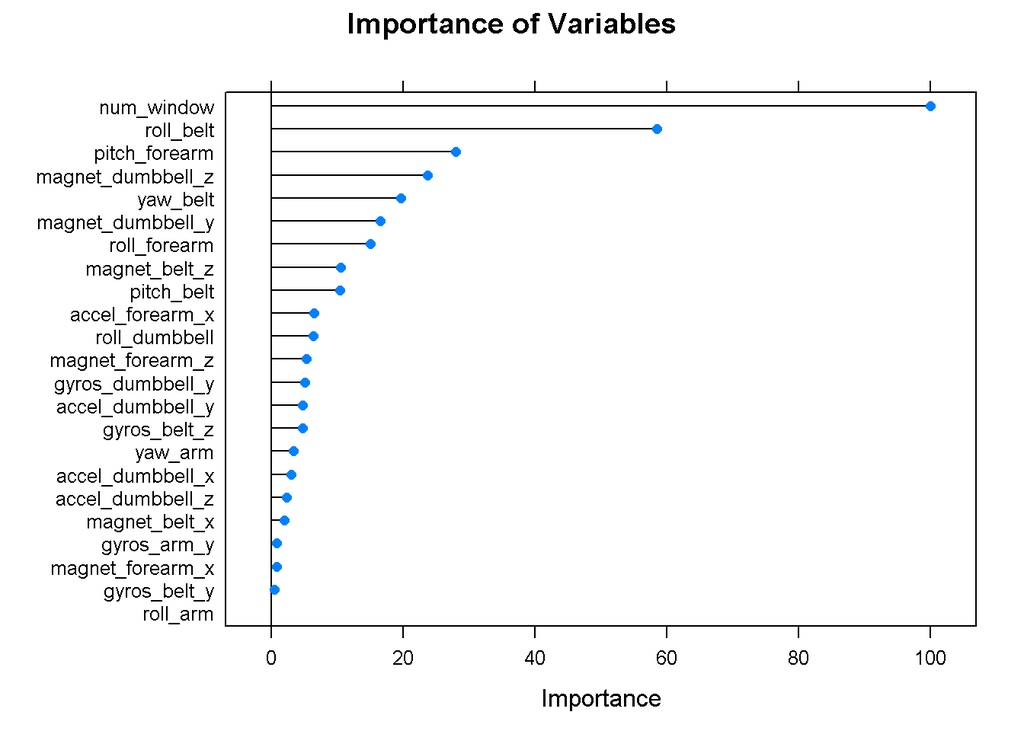

```r
plot(varImpObj, main = "Importance of Variables")
```

### ANSWERS for the quiz from the developed model have been found using the code segment below. the answers are written both to file and to console

```r
path0<-getwd()
pml_write_files = function(x){
n = length(x)
for(i in 1:n){
filename = paste0(path0,"/problem_id_",i,".txt")
write.table(x[i],file=filename,quote=FALSE,row.names=FALSE,col.names=FALSE)
}
}

x <- testing1
answers <- predict(modgbm, newdata=x)
answers
```

```
##  [1] B A B A A E D B A A B C B A E E A B B B
## Levels: A B C D E
```

```r
pml_write_files(answers)
```